# Season report: 4545 Season 25

[figure not shown]

### Overview

- The [season](https://www.lichess4545.com/team4545/season/25/summary/) was played from 8 February 2021 to 5 April 2021.
- 570 players took part, playing 1,774 games in total. The season’s forfeit rate was 3.6 per cent.[^1]
- White won 781 games (44%), 269 games (15.2%) were drawn, and Black won 700 games (39.5%).[^2]
- 1,193 games ended with a resignation, 298 games by checkmate, 13 games by time running out, and 10 games by stalemate.

[figure not shown]

1st place

[The Opposition](https://www.lichess4545.com/team4545/season/25/team/21/)

2nd place

[Hoosier Daddy?](https://www.lichess4545.com/team4545/season/25/team/11/)

3rd place

[The Knights Who Say Ni-dorf](https://www.lichess4545.com/team4545/season/25/team/25/)

| Gold | Silver | Bronze |
| --- | --- | --- |
| Aphla (8) | ATrueRavenclaw (8) | chill5555 (8) |
| ChessPatzerSwan (8) | Drotciv (8) | cristoper (8) |
| esKaayY (8) | scvrf (8) | DubiousChess (8) |
| malbin (8) | SycoraxCirce (8) | exirk (8) |
| penguinsr6 (8) | yerboiMatias (8) | Jebotto (8) |
| rezoons (8) | accool52 (7) | NoviceCitations (8) |
| SlackWyrm (8) | kjfoster17 (7) | Tomato_Xplosion (8) |
| smerlijn (8) | maxivgc (7) | Giulio43532 (7) |
| snorcal (8) | Outbox (7) | Lawkeito (7) |
| Pe-lle (7) | buddhastalin (6) | SuperIntegration (7) |

[output cut: 3 more lines]

#### Story of the season

[figure not shown]

#### Top of the boards

The top player performances by board (minimum 4 games played).[^3]

| Board | Player | Games | Points | Board Perf. |
| --- | --- | --- | --- | --- |
| 1 | lovlas | 8 | 7 | 2549.875 |
| 1 | MoistvonLipwig | 7 | 6 | 2546.57142857143 |
| 1 | Sigrud | 8 | 7 | 2531.875 |
| 1 | FrugoFruit90 | 7 | 6 | 2481.71428571429 |
| 1 | Okoros | 8 | 6 | 2439.125 |
| 2 | maxivgc | 7 | 6 | 2414.85714285714 |
| 2 | chessfish2 | 6 | 5 | 2399.66666666667 |
| 2 | starbaker | 8 | 6.5 | 2339.875 |
| 2 | iOnlyPractice | 8 | 6 | 2312.5 |
| 2 | pendru | 8 | 6 | 2296.125 |

[output cut: 40 more lines]

### Game times / durations

#### When were games played?

[figure not shown]

#### How long did games take?

[figure not shown]

#### Longest games (moves)

*Includes games ranked at or above the 90th percentile by number of moves.*

| Rank | Players / Link | Date | Moves |
| --- | --- | --- | --- |
| 1 | parametric - bufferunderrun | Sun 14 Mar 2021 | 116 |
| 1 | frymealiver - mariuseg | Sun 4 Apr 2021 | 116 |
| 2 | Grzybica - savvyd | Sun 28 Mar 2021 | 112 |
| 3 | Macalda - Wo_Cheng_Si_Le | Sat 13 Feb 2021 | 106 |
| 3 | halifax2345678 - shuvashish76 | Sat 3 Apr 2021 | 106 |
| 4 | Chewbacca_Defense - SundanceKid1019 | Sat 27 Feb 2021 | 104 |
| 5 | Dajrokan - isaypotato | Sun 14 Mar 2021 | 96 |
| 6 | JumpJazz - ljump12 | Thu 25 Mar 2021 | 95 |
| 7 | gjant - kjfoster17 | Sat 20 Feb 2021 | 94 |
| 8 | Ringelnatz - starbaker | Wed 24 Feb 2021 | 92 |

[output cut: 177 more lines]

#### Longest games

*Includes games ranked at or above the 90th percentile by total clock time.*[^4]

| Rank | Players / Link | Date | Total time |
| --- | --- | --- | --- |
| 1 | Grzybica - savvyd | Sun 28 Mar 2021 | 4h 8m 3s |
| 2 | Macalda - Wo_Cheng_Si_Le | Sat 13 Feb 2021 | 3h 58m 46s |
| 3 | parametric - bufferunderrun | Sun 14 Mar 2021 | 3h 58m 38s |
| 4 | Ringelnatz - starbaker | Wed 24 Feb 2021 | 3h 32m 22s |
| 5 | mike_132 - AACtrl | Sat 20 Mar 2021 | 3h 30m 30s |
| 6 | frymealiver - mariuseg | Sun 4 Apr 2021 | 3h 26m 16s |
| 7 | MoistvonLipwig - carc | Fri 19 Feb 2021 | 3h 21m 40s |
| 8 | JumpJazz - ljump12 | Thu 25 Mar 2021 | 3h 21m 6s |
| 9 | rezoons - NoTTwitchy | Wed 3 Mar 2021 | 3h 20m 53s |
| 10 | seius - itsprobablyben | Thu 11 Mar 2021 | 3h 18m 19s |

[output cut: 177 more lines]

### By board / rating band

#### ACPL / blunder rate

[figure not shown]

#### Games with lowest combined ACPL

The games with the lowest combined ACPL (including draws).

| Board | Players / Link | Result | Sum ACPL | Date |
| --- | --- | --- | --- | --- |
| 1 | skyfaller1 - jessehf | 1/2-1/2 | 10 | Sun 28 Mar 2021 |
| 2 | TheKova - mronemore | 1/2-1/2 | 8 | Fri 12 Feb 2021 |
| 3 | y3LL3r - timmah4651 | 1/2-1/2 | 11 | Thu 25 Feb 2021 |
| 4 | Zubenelgenubi - rahulukumar | 1/2-1/2 | 13 | Sun 4 Apr 2021 |
| 5 | Kramopolis - dave3 | 1/2-1/2 | 17 | Sat 27 Feb 2021 |
| 6 | Aphla - plastic_pusher | 1/2-1/2 | 35 | Wed 3 Mar 2021 |
| 7 | kostasvl - onaznam | 1/2-1/2 | 16 | Sat 6 Mar 2021 |
| 8 | ticketyboohoo - SuperIntegration | 1/2-1/2 | 38 | Sat 3 Apr 2021 |
| 9 | BarbarAusBielefeld - JumpJazz | 1/2-1/2 | 31 | Sat 13 Mar 2021 |
| 10 | lvdr - rsava | 1/2-1/2 | 29 | Sat 6 Mar 2021 |

#### Excl. draws

The *decisive* games with the lowest combined ACPL.

| Board | Players / Link | Result | Sum ACPL | Date |
| --- | --- | --- | --- | --- |
| 1 | skyfaller1 - god666 | 1-0 | 11 | Sat 27 Feb 2021 |
| 2 | Fyrox96 - mronemore | 0-1 | 27 | Wed 24 Mar 2021 |
| 3 | Queen_Blunder - gaben1773 | 0-1 | 36 | Mon 22 Feb 2021 |
| 4 | isuckatchess247 - gokuba | 1-0 | 34 | Sun 21 Feb 2021 |
| 4 | mixxanber - rampichino | 1-0 | 34 | Sat 27 Mar 2021 |
| 5 | Lawkeito - PartyMagier | 1-0 | 35 | Wed 17 Mar 2021 |
| 6 | Macalda - Wo_Cheng_Si_Le | 0-1 | 44 | Sat 13 Feb 2021 |
| 7 | RebelMe - BobFisga | 1-0 | 35 | Wed 24 Feb 2021 |
| 8 | Epoch44 - WickidDoc | 0-1 | 45 | Fri 12 Mar 2021 |
| 9 | Goodie1857 - walfie | 1-0 | 34 | Sun 4 Apr 2021 |

[output cut: 1 more lines]

### Openings - tables

#### Popular openings

All openings played in the season, excluding variations.

| Rank | Opening | Games | White % | 1-0 % | Draw % | 0-1 % | Mean Eval | Avg Rating |
| --- | --- | --- | --- | --- | --- | --- | --- | --- |
| 1 | Sicilian Defense | 338 | 50.5917159763314 | 42.8994082840237 | 15.3846153846154 | 41.7159763313609 | 0.617777777777778 | 1899.66124260355 |
| 2 | Caro-Kann Defense | 154 | 50.974025974026 | 43.5064935064935 | 14.9350649350649 | 41.5584415584416 | 0.442368421052632 | 1855.96103896104 |
| 3 | English Opening | 111 | 50.9009009009009 | 42.3423423423423 | 17.1171171171171 | 40.5405405405405 | 0.591 | 1916.57207207207 |
| 4 | French Defense | 110 | 53.6363636363636 | 45.4545454545455 | 16.3636363636364 | 38.1818181818182 | 0.334259259259259 | 1910.50909090909 |
| 5 | Italian Game | 100 | 48.5 | 45 | 7 | 48 | 0.24989247311828 | 1832.21 |
| 6 | Queen's Pawn Game | 77 | 58.4415584415584 | 51.9480519480519 | 12.987012987013 | 35.0649350649351 | 0.54961038961039 | 1812.97402597403 |
| 7 | King's Indian Defense | 71 | 60.5633802816901 | 52.112676056338 | 16.9014084507042 | 30.9859154929577 | 0.427887323943662 | 1908.30985915493 |
| 8 | Queen's Gambit Declined | 70 | 52.8571428571429 | 45.7142857142857 | 14.2857142857143 | 40 | 0.273623188405797 | 1768.90714285714 |
| 9 | Indian Defense | 67 | 54.4776119402985 | 47.7611940298507 | 13.4328358208955 | 38.8059701492537 | 0.855909090909091 | 1861.48507462687 |
| 10 | Ruy Lopez | 62 | 58.0645161290323 | 46.7741935483871 | 22.5806451612903 | 30.6451612903226 | 1.42433333333333 | 1935.96774193548 |

[output cut: 62 more lines]

#### Popular variations

All openings played in the season, including variations.

| Rank | Opening | Games | White % | 1-0 % | Draw % | 0-1 % | Mean Eval | Avg Rating |
| --- | --- | --- | --- | --- | --- | --- | --- | --- |
| 1 | Indian Defense | 31 | 40.3225806451613 | 35.4838709677419 | 9.67741935483871 | 54.8387096774194 | 1.128 | 1861.01612903226 |
| 1 | Sicilian Defense: Closed | 31 | 38.7096774193548 | 32.258064516129 | 12.9032258064516 | 54.8387096774194 | 0.504838709677419 | 1916.67741935484 |
| 2 | Queen's Pawn Game: Mason Variation | 21 | 64.2857142857143 | 57.1428571428571 | 14.2857142857143 | 28.5714285714286 | 0.261904761904762 | 1869.2380952381 |
| 2 | Scandinavian Defense: Mieses-Kotroc Variation | 21 | 47.6190476190476 | 38.0952380952381 | 19.047619047619 | 42.8571428571429 | 1.375 | 1744.92857142857 |
| 3 | English Opening: King's English Variation | 19 | 42.1052631578947 | 31.5789473684211 | 21.0526315789474 | 47.3684210526316 | 0.368947368421053 | 1861.76315789474 |
| 3 | Rapport-Jobava System | 19 | 55.2631578947368 | 47.3684210526316 | 15.7894736842105 | 36.8421052631579 | -0.325555555555556 | 1882.65789473684 |
| 3 | Sicilian Defense: Alapin Variation | 19 | 55.2631578947368 | 47.3684210526316 | 15.7894736842105 | 36.8421052631579 | 0.459473684210526 | 1771.60526315789 |
| 4 | Sicilian Defense: Najdorf Variation, English Attack | 16 | 43.75 | 37.5 | 12.5 | 50 | 0.644666666666667 | 1950.65625 |
| 5 | Italian Game: Two Knights Defense, Polerio Defense, Bishop Check Line | 14 | 57.1428571428571 | 57.1428571428571 | 0 | 42.8571428571429 | 1.37428571428571 | 1851.67857142857 |
| 5 | Queen's Gambit Declined: Exchange Variation, Positional Variation | 14 | 39.2857142857143 | 35.7142857142857 | 7.14285714285714 | 57.1428571428571 | 0.137857142857143 | 1859.35714285714 |

[output cut: 635 more lines]

#### Best for White

The best-scoring main openings for White.

*Includes all main openings played in at least 10 games.*

| Rank | Opening | Games | White's score (%) | White wins (%) | Draws (%) | Black wins (%) | Mean eval after 15 moves | Avg rating |
| --- | --- | --- | --- | --- | --- | --- | --- | --- |
| 1 | Dutch Defense | 28 | 71.4285714285714 | 67.8571428571429 | 7.14285714285714 | 25 | 1.1712 | 1883.35714285714 |
| 2 | Queen's Gambit Accepted | 16 | 68.75 | 62.5 | 12.5 | 25 | 1.630625 | 1778.75 |
| 3 | Benoni Defense | 18 | 63.8888888888889 | 61.1111111111111 | 5.55555555555556 | 33.3333333333333 | 1.575 | 2046.94444444444 |
| 4 | King's Indian Defense | 71 | 60.5633802816901 | 52.112676056338 | 16.9014084507042 | 30.9859154929577 | 0.427887323943662 | 1908.30985915493 |
| 5 | Queen's Indian Defense | 11 | 59.0909090909091 | 36.3636363636364 | 45.4545454545455 | 18.1818181818182 | 0.539090909090909 | 1941.22727272727 |
| 6 | Queen's Pawn Game | 77 | 58.4415584415584 | 51.9480519480519 | 12.987012987013 | 35.0649350649351 | 0.54961038961039 | 1812.97402597403 |
| 7 | Ruy Lopez | 62 | 58.0645161290323 | 46.7741935483871 | 22.5806451612903 | 30.6451612903226 | 1.42433333333333 | 1935.96774193548 |
| 8 | Alekhine Defense | 19 | 55.2631578947368 | 52.6315789473684 | 5.26315789473684 | 42.1052631578947 | 0.837894736842105 | 1887.71052631579 |
| 8 | Rapport-Jobava System | 19 | 55.2631578947368 | 47.3684210526316 | 15.7894736842105 | 36.8421052631579 | -0.325555555555556 | 1882.65789473684 |
| 9 | Indian Defense | 67 | 54.4776119402985 | 47.7611940298507 | 13.4328358208955 | 38.8059701492537 | 0.855909090909091 | 1861.48507462687 |

[output cut: 20 more lines]

#### Best for Black

The best-scoring main openings for Black.

*Includes all main openings played in at least 10 games.*

| Rank | Opening | Games | Black's score (%) | Black wins (%) | Draws (%) | White wins (%) | Mean eval after 15 moves | Avg rating |
| --- | --- | --- | --- | --- | --- | --- | --- | --- |
| 1 | Benko Gambit Accepted | 12 | 70.8333333333333 | 58.3333333333333 | 25 | 16.6666666666667 | 1.54333333333333 | 1911.91666666667 |
| 2 | Nimzo-Indian Defense | 42 | 63.0952380952381 | 57.1428571428571 | 11.9047619047619 | 30.952380952381 | -0.330714285714286 | 1941.27380952381 |
| 3 | Pirc Defense | 17 | 58.8235294117647 | 47.0588235294118 | 23.5294117647059 | 29.4117647058824 | -1.04823529411765 | 1873.79411764706 |
| 4 | Scotch Game | 39 | 55.1282051282051 | 48.7179487179487 | 12.8205128205128 | 38.4615384615385 | 0.469736842105263 | 1765.24358974359 |
| 5 | Scandinavian Defense | 41 | 54.8780487804878 | 48.780487804878 | 12.1951219512195 | 39.0243902439024 | 1.14333333333333 | 1726.84146341463 |
| 6 | Semi-Slav Defense | 31 | 54.8387096774194 | 45.1612903225806 | 19.3548387096774 | 35.4838709677419 | 0.997096774193548 | 1924.85483870968 |
| 7 | Grünfeld Defense | 22 | 52.2727272727273 | 36.3636363636364 | 31.8181818181818 | 31.8181818181818 | 0.0709090909090909 | 1957.22727272727 |
| 8 | Italian Game | 100 | 51.5 | 48 | 7 | 45 | 0.24989247311828 | 1832.21 |
| 9 | Bird Opening | 13 | 50 | 46.1538461538462 | 7.69230769230769 | 46.1538461538462 | 0.065 | 1939.61538461538 |
| 9 | Four Knights Game | 17 | 50 | 47.0588235294118 | 5.88235294117647 | 47.0588235294118 | -1.02785714285714 | 1732.82352941176 |

[output cut: 20 more lines]

#### Popular gambits

All gambit openings played in the season.[^5]

| Rank | Name | Games | White score (%) |
| --- | --- | --- | --- |
| 1 | Smith-Morra Gambit | 22 | 59.0909090909091 |
| 2 | Vienna Gambit | 18 | 52.7777777777778 |
| 3 | Benko Gambit | 17 | 44.1176470588235 |
| 4 | Evans Gambit | 14 | 46.4285714285714 |
| 5 | Greco Gambit | 13 | 30.7692307692308 |
| 6 | Scotch Gambit | 7 | 35.7142857142857 |
| 7 | King's Gambit | 6 | 33.3333333333333 |
| 8 | Staunton Gambit | 5 | 100 |
| 9 | Wing Gambit | 5 | 80 |
| 10 | From's Gambit | 5 | 60 |

[output cut: 26 more lines]

#### Gambiteers

The players who enjoyed the most success when playing gambits.[^6]

*Shows all players who scored at least 50% playing gambits in the season (min. games: 2).*

| Rank | Player | Games | % Score |
| --- | --- | --- | --- |
| 1 | simopippa | 4 | 100 |
| 2 | AndyBarkers | 4 | 50 |
| 2 | MrScribbles | 4 | 50 |
| 3 | ipr | 3 | 100 |
| 4 | SundanceKid1019 | 3 | 83.3333333333333 |
| 5 | dkol | 3 | 66.6666666666667 |
| 5 | liboy | 3 | 66.6666666666667 |
| 6 | gmat20020 | 3 | 50 |
| 7 | jcarmody | 2 | 100 |
| 8 | Epoch44 | 2 | 75 |

[output cut: 13 more lines]

### Openings - sunburst

Click on the image below to see a sunburst plot of all openings played in the season.

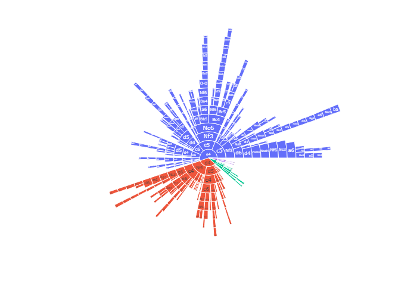

### Awards

Because winning isn’t everything; it’s the only thing :)

See the footnote for further details on selected awards.[^7]

| Award | Description | Winner | Details | Honourable mentions |
| --- | --- | --- | --- | --- |
| x | Archbishop of Accuracy | FrugoFruit90 | 16.5 ACPL over 322 moves | chessnerdbird, rahulukumar |
| x | Awesome Alt | ChewbakaTheRookie | Played for 5 different teams | coolestblue, TBest (4) |
| x | Bullet Boss | shuvashish76 | 30 moves | IsaVulpes, chessfish2 |
| x | David Award | Foxtroxx | Opponents' record: 19.5/22 | Patheticus, jsmithvestal |
| x | Egalitarian Award | We took the green pill | SD: 109.9 |  |
| x | Gambit Guru | simopippa | 100% from 4 games | AndyBarkers, MrScribbles |
| x | Giri Award | bufferunderrun, FearlessKing64, FirstnameLastname, gavalanche20, iOnlyPractice, pendru, rock840, ssyx, Svendra, The_Wayward_Prince | 4 draws |  |
| x | Grischuk's Cousin | Sigrud | Had 8m 5s left after 10 moves | Tomato_Xplosion, seius |
| x | Houdini Award | simopippa |  | yerboiMatias, liboy |
| x | Intimate with Increment | seius | 36.6% | AACtrl, pepepibote |

[output cut: 10 more lines]

### Detailed statistics

All the following tables are sortable and searchable.

#### Team statistics

| rank | Team | games | points | pts_nonforf | wins | draws | losses | players | avg_moves | ACPL | blunder_pc |
| --- | --- | --- | --- | --- | --- | --- | --- | --- | --- | --- | --- |
| 1 | The Opposition | 80 | 44.5 | 44.5 | 39 | 11 | 30 | 11 | 41.3 | 38.30901937046 | 3.57142857142857 |
| 2 | Hoosier Daddy? | 77 | 48 | 46 | 42 | 8 | 27 | 13 | 40.2857142857143 | 44.8033526756931 | 3.86847195357834 |
| 3 | The Knights Who Say Ni-dorf | 78 | 48 | 48 | 43 | 10 | 25 | 11 | 40.0512820512821 | 42.039052496799 | 4.3213828425096 |
| 4 | En Croissant | 79 | 47.5 | 45.5 | 39 | 13 | 27 | 10 | 42.2405063291139 | 43.1159724303266 | 4.70482469283788 |
| 5 | My wife also likes that | 78 | 47 | 46 | 38 | 16 | 24 | 13 | 39.5512820512821 | 48.4275526742301 | 5.18638573743922 |
| 6 | Team 28 | 76 | 45 | 42.5 | 37 | 11 | 28 | 14 | 41.8815789473684 | 41.0587496072887 | 4.14703110273327 |
| 7 | Run van Foreest Run | 73 | 41 | 37.5 | 34 | 7 | 32 | 15 | 40.6027397260274 | 49.1491228070175 | 5.49932523616734 |
| 8 | The Undiscovered Attack | 75 | 46.5 | 42.5 | 34 | 17 | 24 | 14 | 39.08 | 45.2934152166496 | 4.33299215284886 |
| 9 | A farewell to pawns | 77 | 43.5 | 40.5 | 37 | 7 | 33 | 16 | 39.987012987013 | 45.9600519649237 | 4.09223773952582 |
| 10 | YAS QUEEN | 79 | 43.5 | 42.5 | 37 | 11 | 31 | 11 | 42.4556962025316 | 45.7856290995826 | 4.65116279069767 |

[output cut: 36 more lines]

#### Best performances / highest accuracy

##### Best relative perfs

Shows players’ *relative* performance ratings: season performance rating minus initial rating.[^8]

*Includes all players with a positive relative performance rating over at least five games.*

| # | Player | Games | W | D | L | Initial | Perf | Diff. |
| --- | --- | --- | --- | --- | --- | --- | --- | --- |
| 1 | chessnerdbird | 7 | 7 | 0 | 0 | 1644 | 2519.85714285714 | 875.857142857143 |
| 2 | simopippa | 8 | 8 | 0 | 0 | 1517 | 2364.25 | 847.25 |
| 3 | z0x | 8 | 7 | 0 | 1 | 1384 | 1840.125 | 456.125 |
| 4 | Ixitixl | 8 | 7 | 0 | 1 | 1694 | 2097.375 | 403.375 |
| 5 | Tomato_Xplosion | 7 | 6 | 1 | 0 | 1522 | 1902.85714285714 | 380.857142857143 |
| 6 | RaisinBranCrunch | 7 | 5 | 2 | 0 | 1916 | 2283.14285714286 | 367.142857142857 |
| 7 | forevern00b | 5 | 4 | 1 | 0 | 1907 | 2269 | 362 |
| 8 | Karpyan | 8 | 6 | 2 | 0 | 1873 | 2211.5 | 338.5 |
| 9 | yerboiMatias | 8 | 6 | 2 | 0 | 1652 | 1988.75 | 336.75 |
| 10 | Felipekaox | 7 | 6 | 0 | 1 | 1750 | 2085.28571428571 | 335.285714285714 |

[output cut: 209 more lines]

##### Lowest ACPL

*Includes the 100 players with the lowest ACPL (min. 100 moves played).*

| Rank | Player | Moves | ACPL |
| --- | --- | --- | --- |
| 1 | FrugoFruit90 | 322 | 16.5155279503106 |
| 2 | chessnerdbird | 193 | 18.720207253886 |
| 3 | rahulukumar | 128 | 18.8671875 |
| 4 | MoistvonLipwig | 328 | 20.5701219512195 |
| 5 | TheKova | 338 | 21.3047337278106 |
| 6 | connerator | 235 | 21.7829787234043 |
| 7 | ARandomMove | 168 | 22 |
| 8 | Razorneck | 332 | 22.4969879518072 |
| 9 | Der_Bo | 316 | 23.4525316455696 |
| 10 | FlokiTheCat | 134 | 23.5746268656716 |

[output cut: 90 more lines]

#### Time spent / strongest opponents

##### Time spent

*Includes the 50 players who spent the most clock time over the season.*

| Rank | Player | Games | Total time spent |
| --- | --- | --- | --- |
| 1 | Lupo_Jones | 9 | 10h 55m 31s |
| 2 | Grzybica | 8 | 10h 53m 12s |
| 3 | seius | 8 | 10h 52m 12s |
| 4 | frymealiver | 8 | 10h 26m 27s |
| 5 | adande1 | 8 | 10h 18m 41s |
| 6 | SundanceKid1019 | 8 | 10h 14m 31s |
| 7 | savvyd | 8 | 10h 14m 24s |
| 8 | Mackjalek97 | 8 | 10h 2m 39s |
| 9 | parametric | 8 | 10h 1m 2s |
| 10 | AACtrl | 8 | 10h 0m 13s |

[output cut: 40 more lines]

##### Time spent per move (after move 10)

*Includes everyone who played at least three games.*

| Rank | Player | Games | Moves | Time spent per move | Percentile |
| --- | --- | --- | --- | --- | --- |
| 1 | CalculatedChess | 3 | 40 | 2m 38.1s | 100 |
| 2 | tommysim | 6 | 99 | 2m 33.1s | 100 |
| 3 | Queen_Blunder | 6 | 134 | 2m 20.7s | 100 |
| 4 | coolestblue | 5 | 119 | 2m 19.5s | 100 |
| 5 | FearlessKing64 | 6 | 142 | 2m 19.1s | 99 |
| 6 | ATrueRavenclaw | 8 | 171 | 2m 18.7s | 99 |
| 7 | fhunfi | 8 | 168 | 2m 17.1s | 99 |
| 8 | AndreCMorais | 3 | 62 | 2m 16.5s | 99 |
| 9 | AnikiaN | 4 | 86 | 2m 13.6s | 98 |
| 10 | oleksiial | 8 | 143 | 2m 11.7s | 98 |

[output cut: 473 more lines]

##### Strength of schedule

These players faced the most in-form opponents across the season, when judged by their opponents’ collective score in all their other games.[^9]

*Includes all players who faced a collective group of opponents that played at least 15 (other) games across the season with a collective score above 50 per cent.*

| # | Player | Opp Games | Opp Pts | Opp % |
| --- | --- | --- | --- | --- |
| 1 | Foxtroxx | 22 | 19.5 | 88.6363636363636 |
| 2 | Patheticus | 23 | 18 | 78.2608695652174 |
| 3 | jsmithvestal | 25 | 18.5 | 74 |
| 4 | shadesedge | 21 | 15.5 | 73.8095238095238 |
| 5 | Daansn3 | 28 | 19.5 | 69.6428571428571 |
| 6 | victormanolo | 48 | 32.5 | 67.7083333333333 |
| 7 | gigantaure | 49 | 33 | 67.3469387755102 |
| 8 | tommysim | 26 | 17.5 | 67.3076923076923 |
| 9 | SundanceKid1019 | 53 | 35.5 | 66.9811320754717 |
| 10 | SuperIntegration | 42 | 28 | 66.6666666666667 |

[output cut: 253 more lines]

#### Comebacks and upsets

##### Comebacks

*Includes players with a positive average “comeback margin” that played at least three games.*[^10]

| Rank | Player | Average Comeback Margin | Total Comeback Margin |
| --- | --- | --- | --- |
| 1 | simopippa | 1.40400738724553 | 11.2320590979642 |
| 2 | yerboiMatias | 1.36221701153797 | 10.8977360923037 |
| 3 | liboy | 1.26218700112018 | 10.0974960089614 |
| 4 | Ixitixl | 1.2438292862748 | 9.95063429019837 |
| 5 | Tomato_Xplosion | 1.1780508169454 | 9.42440653556323 |
| 6 | NoviceCitations | 1.17364228693553 | 9.38913829548423 |
| 7 | starbaker | 1.13094598678255 | 9.04756789426043 |
| 8 | Felipekaox | 1.28194414885184 | 8.9736090419629 |
| 9 | Sesquipedalism | 1.11302746737889 | 8.90421973903108 |
| 10 | z0x | 1.11258150759319 | 8.90065206074549 |

[output cut: 462 more lines]

##### Biggest upsets

*Includes all players who defeated an opponent rated at least 50 points higher.*

| Rank | Player | Upset Margin |
| --- | --- | --- |
| 1 | Cornelius25 | 316 |
| 2 | z0x | 238 |
| 3 | Eshpy | 208 |
| 4 | Tororoi | 205 |
| 5 | z0x | 189 |
| 6 | electricfalcon | 188 |
| 7 | ChewieMarbles | 171 |
| 8 | mariuseg | 159 |
| 9 | Ironvil | 156 |
| 9 | LandyPJY | 156 |

[output cut: 171 more lines]

##### Repeated upsets

Includes players who achieved multiple wins over opponents rated at least 50 points higher.

| Rank | Player | Total Upset Margin | Upsets | Avg Upset Margin | Biggest Margin |
| --- | --- | --- | --- | --- | --- |
| 1 | z0x | 578 | 3 | 192.666666666667 | 238 |
| 2 | Ironvil | 387 | 3 | 129 | 156 |
| 3 | Tororoi | 355 | 2 | 177.5 | 205 |
| 4 | Foxtroxx | 310 | 3 | 103.333333333333 | 113 |
| 5 | moleSG | 290 | 3 | 96.6666666666667 | 126 |
| 6 | Eshpy | 282 | 2 | 141 | 208 |
| 7 | Daansn3 | 268 | 2 | 134 | 144 |
| 8 | netherfiel | 236 | 3 | 78.6666666666667 | 100 |
| 9 | LandyPJY | 219 | 2 | 109.5 | 156 |
| 10 | DubiousChess | 215 | 2 | 107.5 | 137 |

[output cut: 18 more lines]

#### Dawdlers and instant movers

##### Least time left after move 10

The players with the least time left after 10 moves…who still managed to win![^11]

| Rank | Player | Time left after 10 moves | Link |
| --- | --- | --- | --- |
| 1 | Sigrud | 8m 5s | https://lichess.org/4rEQMDfL#20 |
| 2 | Tomato_Xplosion | 12m 30s | https://lichess.org/Nxp4RJSi#20 |
| 3 | seius | 13m 49s | https://lichess.org/pZqu9hTU#20 |
| 4 | pepepibote | 14m 12s | https://lichess.org/EakN2rdr#20 |
| 5 | FrugoFruit90 | 17m 11s | https://lichess.org/P6TzruAB#20 |
| 6 | Seth_Lichtenstein | 18m 27s | https://lichess.org/kBVoRRuO#20 |
| 7 | Zopherus | 18m 40s | https://lichess.org/7ToddvzT#20 |
| 8 | Marsh_Knight | 19m 18s | https://lichess.org/mbxlL2Aa#20 |
| 9 | Seb32 | 20m 31s | https://lichess.org/0aoMxIC0#20 |
| 10 | thatoneguy1475 | 21m 31s | https://lichess.org/vi5Xn7tJ#20 |

##### Instant moves

Players who made the most ‘instant’ moves over the season, taking less than 0.5 seconds (includes premoves).

*Includes players with more than five ‘instant’ moves.*

| Rank | Player | Instant moves |
| --- | --- | --- |
| 1 | shuvashish76 | 30 |
| 2 | IsaVulpes | 22 |
| 3 | chessfish2 | 21 |
| 3 | jessehf | 21 |
| 4 | esKaayY | 20 |
| 5 | k-night-moves | 19 |
| 5 | seius | 19 |
| 5 | theknugdorf | 19 |
| 6 | forevern00b | 18 |
| 6 | Ritterburg | 18 |

[output cut: 135 more lines]

#### Longest thinks, time trouble addicts, and lucky escapes

##### Longest thinks

The longest times spent on a single move.

*Top 100 shown.*

| # | Player | Time spent | Colour | Move | Link |
| --- | --- | --- | --- | --- | --- |
| 1 | Silver124 | 38m 36s | White | 16 | https://lichess.org/Sjbpnb76#31 |
| 2 | hhh1001 | 37m 17s | Black | 27 | https://lichess.org/tCH1SkgU#54 |
| 3 | Shrekmated | 31m 21s | Black | 21 | https://lichess.org/fzBX2wpN#42 |
| 4 | toddletales | 29m 54s | Black | 34 | https://lichess.org/GYGWQ39G#68 |
| 5 | Bjorgvin1 | 27m 55s | Black | 20 | https://lichess.org/9dvsWGzV#40 |
| 6 | mathijshuis | 26m 46s | Black | 14 | https://lichess.org/XM1ZVi4b#28 |
| 6 | LucaGaglia73 | 26m 46s | Black | 13 | https://lichess.org/7QkCsjWz#26 |
| 7 | Gatzb | 26m 36s | White | 56 | https://lichess.org/Nxp4RJSi#111 |
| 8 | aloo_bhaloo | 25m 32s | White | 21 | https://lichess.org/vPpxEvzI#41 |
| 9 | DJ-Logan | 25m 9s | White | 15 | https://lichess.org/osbAJ7b4#29 |

[output cut: 90 more lines]

##### Time trouble addicts

Shows players by proportion of moves made in time trouble (defined as having less than a minute remaining on the clock).

*Includes everyone who played at least 100 moves over the season while making at least one move in time trouble.*

| # | Player | All moves | With < 1min left | Time Trouble % |
| --- | --- | --- | --- | --- |
| 1 | seius | 440 | 161 | 0.365909090909091 |
| 2 | AACtrl | 355 | 124 | 0.349295774647887 |
| 3 | pepepibote | 270 | 77 | 0.285185185185185 |
| 4 | HNorbi96 | 301 | 78 | 0.259136212624585 |
| 5 | lazerpo | 280 | 71 | 0.253571428571429 |
| 6 | texaspete09 | 296 | 71 | 0.239864864864865 |
| 7 | Grzybica | 406 | 92 | 0.226600985221675 |
| 8 | k-night-moves | 261 | 58 | 0.222222222222222 |
| 9 | TheRatRiverTrapper | 232 | 48 | 0.206896551724138 |
| 10 | synapz | 278 | 56 | 0.201438848920863 |

[output cut: 256 more lines]

##### Saved by the bell

Players who made moves with under 5 seconds left on their clock…and still won![^12]

| Player | Moves with under 5s left | Least time left | Link |
| --- | --- | --- | --- |
| Wo_Cheng_Si_Le | 14 | 0 | https://lichess.org/TRGzaCM3 |
| kschmigel | 5 | 0 | https://lichess.org/xdoAZ6gU |
| gkroch | 4 | 0 | https://lichess.org/xAHk21Kq |
| Champignon | 3 | 2 | https://lichess.org/I3xPKtaa |
| kamelstekspizza | 3 | 3 | https://lichess.org/RBdDHLoI |
| loungelizard | 2 | 1 | https://lichess.org/EuSjx2nS |
| sidetracked_owl | 2 | 1 | https://lichess.org/2KR3NCh6 |
| lc91 | 2 | 2 | https://lichess.org/iaLJwOp1 |
| AACtrl | 2 | 2 | https://lichess.org/m6tODMSp |
| seius | 2 | 3 | https://lichess.org/pZqu9hTU |

[output cut: 7 more lines]

#### Misc. facts

##### Lesser spotted mates

A pawn gave checkmate in 8 games: https://lichess.org/8aHiN8UU, https://lichess.org/kkqj3rZq, https://lichess.org/Nx6YvCVA, https://lichess.org/HXfiSoWd, https://lichess.org/1MOdCABz, https://lichess.org/LQsRXK8R, https://lichess.org/x6T3O1Xw, https://lichess.org/0eh8h8hw.

A knight gave checkmate in 12 games: https://lichess.org/F959PppU, https://lichess.org/J3iWEngQ, https://lichess.org/aNuRhlSW, https://lichess.org/J9q9PkNu, https://lichess.org/gfOYMvDW, https://lichess.org/VpLZ5pKL, https://lichess.org/CAglI75I, https://lichess.org/igEZrArC, https://lichess.org/bdRslbpl, https://lichess.org/FGkKfvjL, https://lichess.org/j2YiEd7W, https://lichess.org/QjOkzB4t.

##### Promotions

231 games had at least one promotion. 8 of these saw an under-promotion.

The most promotions seen in a game was 4: https://lichess.org/Cxyb5avt, https://lichess.org/VjYLyNSf

##### Rollercoaster games

221 games featured significant winning chances for both sides (as identified by Lichess’s server analysis), comprising 12.5% of all games played.

##### Checks and captures

- Most consecutive checks: 23 (https://lichess.org/LOD6uHzu)
- Most consecutive captures: 10 (https://lichess.org/1STexAyp, https://lichess.org/awahvElr, https://lichess.org/dqbiZs7d, https://lichess.org/E9lk1iUx, https://lichess.org/ZaPiYfor)
- Latest-occurring first capture: ply 47 in https://lichess.org/ypuBcPpp